# PCA of Surface Energy Fluxes and Ice Thickness

## Data

Each observation is **one lake in one month of one year**. The variables are the monthly means of each surface flux type (W m⁻²) and the monthly mean ice thickness (m). Only ice-covered hours are used, and months with fewer than 10 ice-covered days are dropped. That leaves **505 observations** across 6 lakes.

Every variable is centred and scaled to unit variance before the PCA. Without that, the large radiative fluxes and the metre-scale thickness would dominate just because of their units.

Observations per lake

| Region | Lake | Months | Output last written |
| --- | --- | --- | --- |
| McMurdo Dry Valleys | West Lake Bonney | 83 | 2026-10-09 13:23 |
| McMurdo Dry Valleys | East Lake Bonney | 84 | 2026-10-09 13:24 |
| McMurdo Dry Valleys | Lake Hoare | 84 | 2026-10-09 13:24 |
| McMurdo Dry Valleys | Lake Fryxell | 84 | 2026-10-09 13:24 |
| Colorado Rockies | Green Lake 4 | 104 | 2026-10-09 13:25 |
| Colorado Rockies | The Loch | 66 | 2026-10-09 13:25 |

### How the variables relate

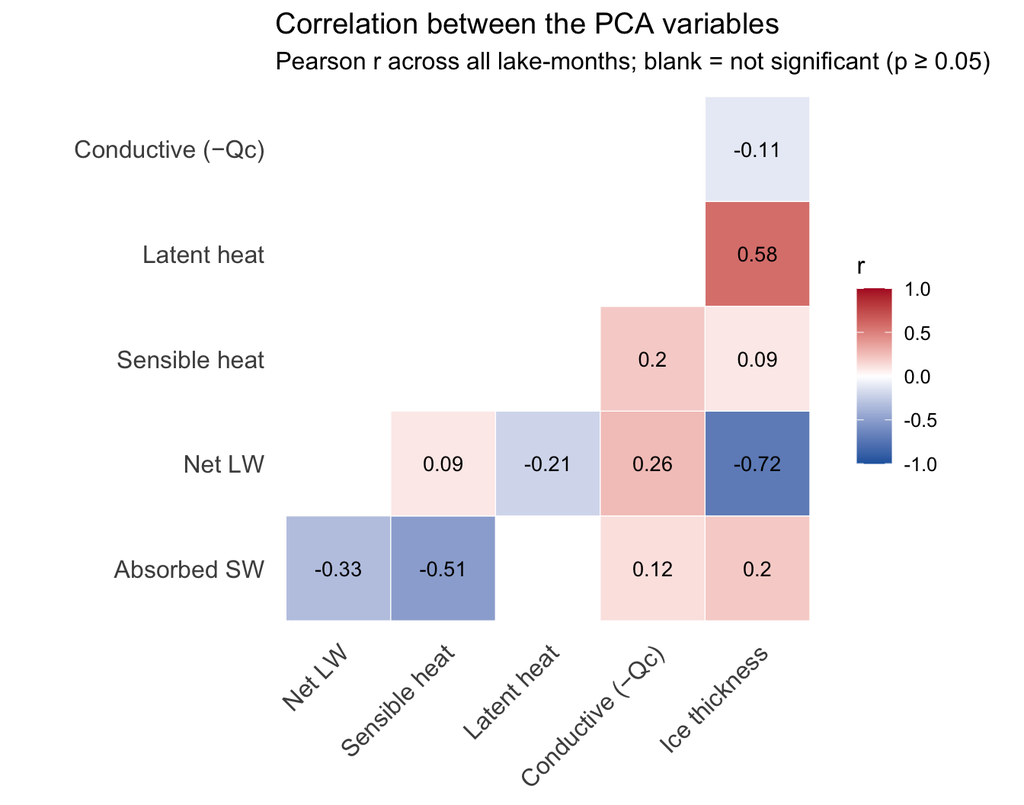

12 of 15 variable pairs are significant at p < 0.05. With 505 lake-months, even |r| ≈ 0.09 counts as significant, and consecutive months within a lake are not independent, so these p-values are optimistic. Treat the blank cells as “no evidence of a relationship” rather than the coloured ones as proof of one.

## PCA results

### Variance explained

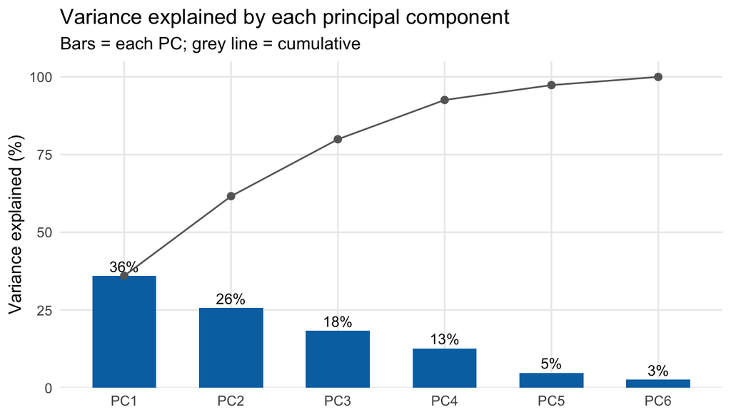

PC1 explains 36% of the variance and PC2 explains 26%. Together the first two components capture 62%, and the first three capture 80%.

### Loadings

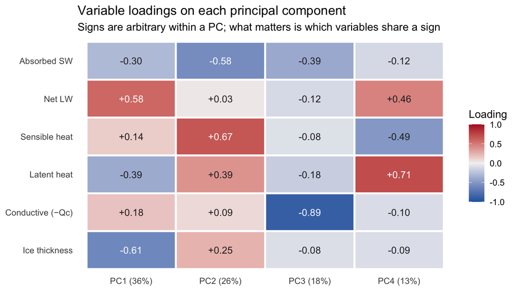

- **PC1 (36%)**: high scores mean high Net LW and low Ice thickness, Latent heat. Lakes with the highest mean score: The Loch, Green Lake 4; lowest: Lake Fryxell, Lake Hoare.
- **PC2 (26%)**: high scores mean high Sensible heat, Latent heat and low Absorbed SW. Lakes with the highest mean score: Lake Fryxell, East Lake Bonney; lowest: Green Lake 4, The Loch.
- **PC3 (18%)**: high scores mean low Conductive (−Qc), Absorbed SW. Lakes with the highest mean score: The Loch, Green Lake 4; lowest: Lake Fryxell, East Lake Bonney.

The descriptions above list variables with |loading| ≥ 0.35.

### Biplots

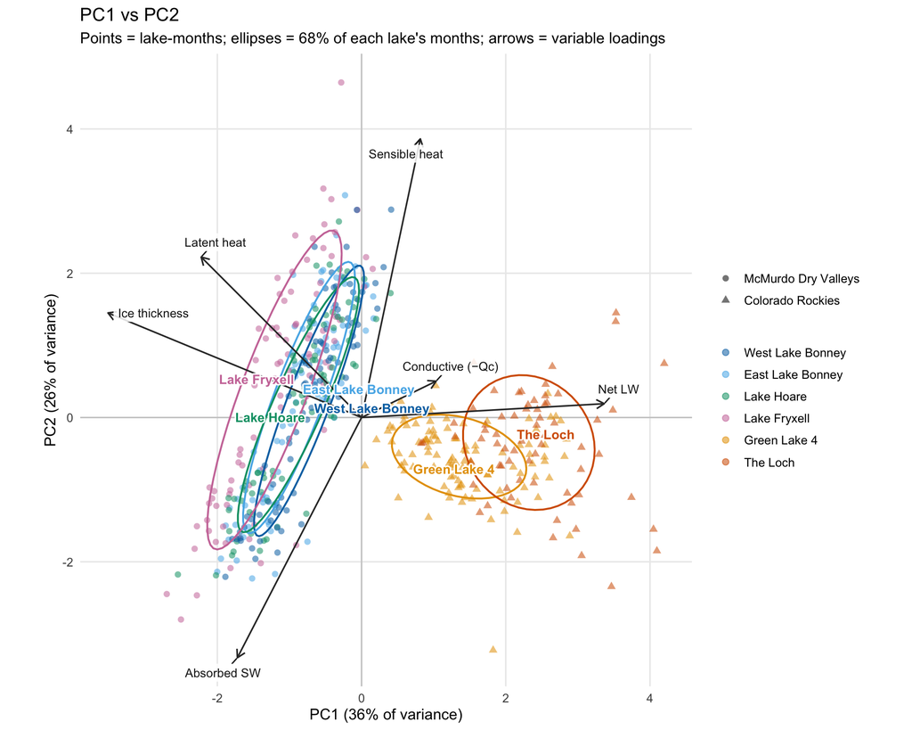

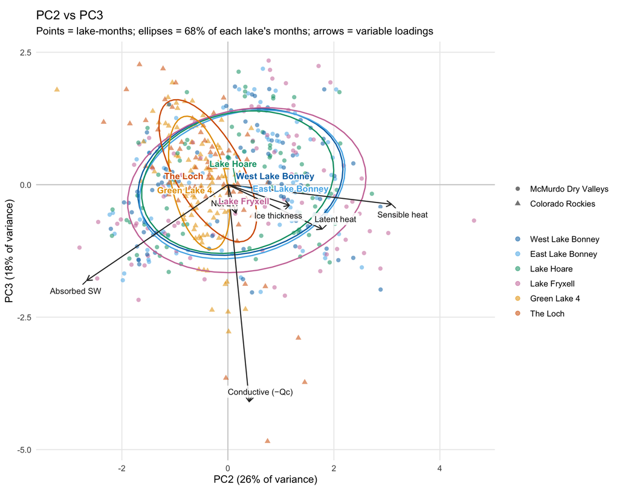

### Seasonal paths through PC space

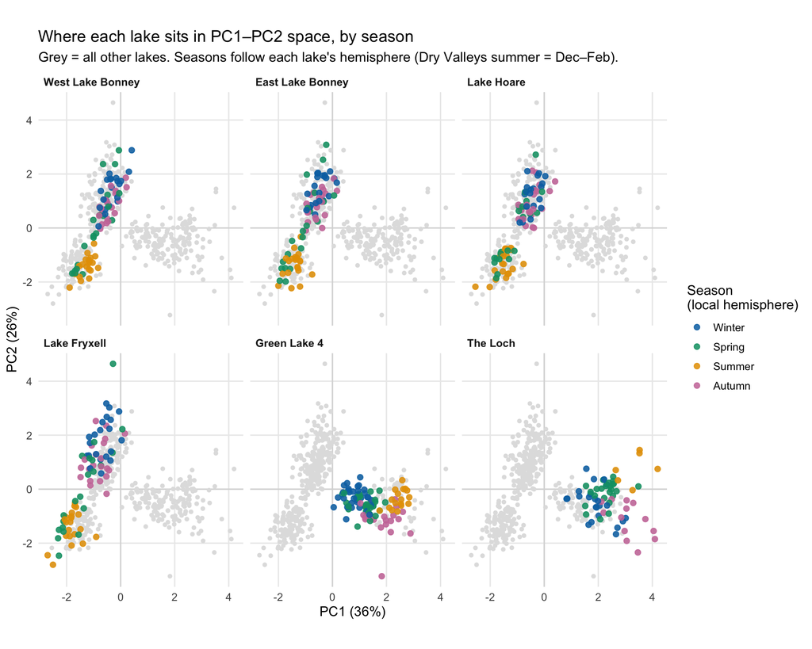

### Lake mean scores

Mean ± SD of each lake’s PC scores

| Region | Lake | PC1 | PC2 | PC3 |
| --- | --- | --- | --- | --- |
| McMurdo Dry Valleys | West Lake Bonney | -0.74 ± 0.55 | +0.22 ± 1.35 | -0.00 ± 0.99 |
| McMurdo Dry Valleys | East Lake Bonney | -0.87 ± 0.55 | +0.24 ± 1.35 | -0.03 ± 1.01 |
| McMurdo Dry Valleys | Lake Hoare | -0.88 ± 0.60 | +0.15 ± 1.26 | +0.03 ± 0.96 |
| McMurdo Dry Valleys | Lake Fryxell | -1.18 ± 0.66 | +0.39 ± 1.60 | -0.13 ± 1.11 |
| Colorado Rockies | Green Lake 4 | +1.43 ± 0.70 | -0.56 ± 0.50 | +0.03 ± 0.97 |
| Colorado Rockies | The Loch | +2.41 ± 0.74 | -0.38 ± 0.75 | +0.12 ± 1.30 |

Loadings (eigenvectors)

| Variable | PC1 | PC2 | PC3 | PC4 |
| --- | --- | --- | --- | --- |
| Absorbed SW | -0.298 | -0.577 | -0.392 | -0.123 |
| Net LW | +0.583 | +0.033 | -0.116 | +0.462 |
| Sensible heat | +0.141 | +0.669 | -0.080 | -0.493 |
| Latent heat | -0.385 | +0.385 | -0.181 | +0.714 |
| Conductive (−Qc) | +0.179 | +0.087 | -0.887 | -0.099 |
| Ice thickness | -0.609 | +0.251 | -0.084 | -0.093 |

## Notes

- **The results depend on the model version.** The fluxes come from the saved model outputs, so the PCA reflects whatever version of `functions.R` produced them (shown in the “Output last written” column above). The turbulent fluxes in particular will change once the surface-temperature fix is in.
- **Thickness separates the regions.** Perennial Dry Valley ice is roughly 3–5 m thick and seasonal Rockies ice is under about 1 m, so thickness alone pulls the two regions apart. To see how flux patterns differ apart from thickness, remove `thickness` from `pca_vars`.
- **Monthly observations are not independent.** Months within a lake are autocorrelated, so the PCA is for describing and comparing lakes, not for significance tests.